# mh_google_cloud_bigquery_ltv_prediction_challenge_EDA

### Build a model that can predict customers' Long Term Value (LTV).

#### Import Necessary Libraries and Packages

```python
pip install klib -q
```

[output not shown]

```python
import numpy as np # linear algebra
import pandas as pd # data processing, CSV file I/O (e.g. pd.read_csv)
import seaborn as sns # visualization
from matplotlib import pyplot as plt # visualization
import klib
%matplotlib inline
import warnings
warnings.filterwarnings("ignore")
import re
from google.cloud import bigquery
```

#### Setup project id for to connect with google bigquery

```python
PROJECT_ID = "my-project-1480770657959"
if PROJECT_ID == "" or PROJECT_ID is None:
  PROJECT_ID = "PUT_YOUR_PROJECT_ID_HERE"

PROJECT_ID
```

```
'my-project-1480770657959'
```

```python
import os
import sys

# If you are running this notebook in Colab, run this cell and follow the
# instructions to authenticate your GCP account. This provides access to your
# Cloud Storage bucket and lets you submit training jobs and prediction
# requests.

# The Google Cloud Notebook product has specific requirements
IS_GOOGLE_CLOUD_NOTEBOOK = os.path.exists("/opt/deeplearning/metadata/env_version")

# If on Google Cloud Notebooks, then don't execute this code
if not IS_GOOGLE_CLOUD_NOTEBOOK:
    if "google.colab" in sys.modules:
        from google.colab import auth as google_auth

        google_auth.authenticate_user()

    # If you are running this notebook locally, replace the string below with the
    # path to your service account key and run this cell to authenticate your GCP
    # account.
    elif not os.getenv("IS_TESTING"):
        %env GOOGLE_APPLICATION_CREDENTIALS ''
```

```python
#Client manages connections to the BigQuery API and helps
#bundle configuration (project, credentials) needed for API requests.
client = bigquery.Client(PROJECT_ID)

# to make sure all columns are displayed while working with dataframe
pd.set_option('display.max_columns', None)
```

#### Dataset and table name

```python
PROJECT_ID_DATA = "mh-hackathon"
DATASET_ID_DATA = "ga4_data"
TABLE_ID_TRAIN  = "ga4_train"
TABLE_ID_TEST  = "ga4_test"
START_DATE = "20201101"
END_DATE = "20210131"
```

#### Function for boxplot

```python
def box_plot(df,col,rot=None):
  _=plt.figure(figsize=(8,6))
  _=sns.boxplot(y=df[col])
  _=plt.title(col.capitalize()+" Distribution",fontsize=25)
  _=plt.ylabel(col,fontsize=20,rotation=rot)
  _=plt.yticks(fontsize=14)
```

#### Function to show group by numberical values distribution in density and box plot.

```python
def side_by_side_plot(df,grp,valcol,rot=None,title=""):
    clr="Paired"
    fig,(ax1,ax2) = plt.subplots(1,2,figsize=(18,6))
    fig.tight_layout()
    sns.kdeplot(x=df[valcol], hue=df[grp],ax=ax1,palette=clr)
    ax1.set_title(grp.capitalize()+" Wise "+title+" Distribution",size=15)
    ax1.set_xlabel(valcol,fontsize=20)
    sns.boxplot(x=df[grp],y=df[valcol],ax=ax2,palette=clr)
    ax2.set_title(grp.capitalize()+" Wise "+title+" Distribution",size=15)
    ax2.set_xlabel(grp,fontsize=20)
    ax2.tick_params(rotation=rot)
```

#### Let's see the table structure

```python
query = f"""
SELECT
  DISTINCT(column_name),
  data_type
FROM
  `{PROJECT_ID_DATA}.{DATASET_ID_DATA}.INFORMATION_SCHEMA.COLUMNS`
"""

query_job = client.query(query)
predict_data = query_job.to_dataframe()
predict_data
```

|  | column_name | data_type |
| --- | --- | --- |
| 0 | user_pseudo_id | STRING |
| 1 | event_date | STRING |
| 2 | event_timestamp | INT64 |
| 3 | event_name | STRING |
| 4 | event_params | ARRAY<STRUCT<key STRING, value STRUCT<string_v... |
| 5 | event_previous_timestamp | INT64 |
| 6 | event_value_in_usd | FLOAT64 |
| 7 | event_bundle_sequence_id | INT64 |
| 8 | event_server_timestamp_offset | INT64 |
| 9 | user_id | STRING |
| 10 | privacy_info | STRUCT<analytics_storage INT64, ads_storage IN... |
| 11 | user_properties | ARRAY<STRUCT<key INT64, value STRUCT<string_va... |
| 12 | user_first_touch_timestamp | INT64 |
| 13 | device | STRUCT<category STRING, mobile_brand_name STRI... |
| 14 | geo | STRUCT<continent STRING, sub_continent STRING,... |
| 15 | app_info | STRUCT<id STRING, version STRING, install_stor... |
| 16 | traffic_source | STRUCT<medium STRING, name STRING, source STRING> |
| 17 | stream_id | INT64 |
| 18 | platform | STRING |
| 19 | event_dimensions | STRUCT<hostname STRING> |
| 20 | ecommerce | STRUCT<total_item_quantity INT64, purchase_rev... |
| 21 | items | ARRAY<STRUCT<item_id STRING, item_name STRING,... |
| 22 | ltv | FLOAT64 |

#### Let's see the shape of the data

```python
query=f"""
SELECT
  count(*)
FROM
  `{PROJECT_ID_DATA}.{DATASET_ID_DATA}.{TABLE_ID_TRAIN}`
"""
query_job = client.query(query)
query_job.to_dataframe()
```

|  | f0_ |
| --- | --- |
| 0 | 3859763 |

#### The train dataset has 3 million rows

#### Let's see how many unique psuedo user id in train dataset

```python
query=f"""
SELECT
  count(distinct user_pseudo_id) as unique_user_pseudo_id
FROM
  `{PROJECT_ID_DATA}.{DATASET_ID_DATA}.{TABLE_ID_TRAIN}`
"""
query_job = client.query(query)
query_job.to_dataframe()
```

|  | unique_user_pseudo_id |
| --- | --- |
| 0 | 243394 |

#### The train dataset has 243394 unique user pseudo id.

#### Let's see the total null values in by string, int64, float64 data types columns.

```python
def query_to_df(field_list):
  null_count=[]
  for param in field_list:
    query=f"""SELECT
    sum(CASE WHEN {param} IS NULL THEN 1 ELSE 0 END) as {re.sub(".","_",param)}
    FROM
      `{PROJECT_ID_DATA}.{DATASET_ID_DATA}.{TABLE_ID_TRAIN}`
    """
    query_job = client.query(query)
    df=query_job.to_dataframe()
    null_count.append(df.iloc[:,[0]].values[0][0])
  return pd.DataFrame({'column_name':field_list,'null_value_count':null_count})
```

```python
def null_count_plot(df,x,y):
  _=plt.figure(figsize=(12,6))
  sns.barplot(x=df[x],y=df[y]);
```

```python
col_list=['event_date', 'event_timestamp', 'event_name', 'event_previous_timestamp',
            'event_value_in_usd',
            'event_bundle_sequence_id',
            'event_server_timestamp_offset',
            'user_id',
            'user_first_touch_timestamp',
            'stream_id', 'platform']

null_count_by_col=query_to_df(col_list)
```

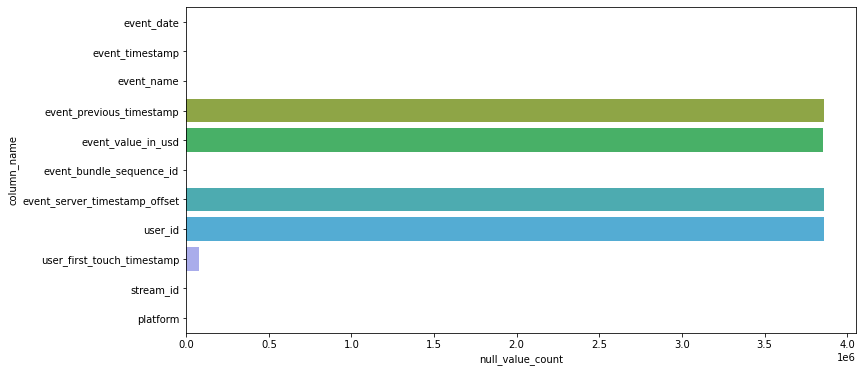

```python
null_count_plot(null_count_by_col,'null_value_count','column_name')
```

```python
null_count_by_col
```

|  | column_name | null_value_count |
| --- | --- | --- |
| 0 | event_date | 0 |
| 1 | event_timestamp | 0 |
| 2 | event_name | 0 |
| 3 | event_previous_timestamp | 3859763 |
| 4 | event_value_in_usd | 3855007 |
| 5 | event_bundle_sequence_id | 0 |
| 6 | event_server_timestamp_offset | 3859763 |
| 7 | user_id | 3859763 |
| 8 | user_first_touch_timestamp | 78423 |
| 9 | stream_id | 0 |
| 10 | platform | 0 |

#### The above information explain that the columns event_previous_timestamp, event_value_in_usd, event_server_timestamp_offset,user_id have almost null values for all rows.

#### The user_first_touch_timestamp column has 78423 null values.

#### Let's see the structure datatype columns and null value count of each field.

#### Let's see the privacy info column and its fields' null value count.

```python
field_list=['privacy_info.analytics_storage','privacy_info.ads_storage','privacy_info.uses_transient_token']
privacy_info_null_count=query_to_df(field_list)
```

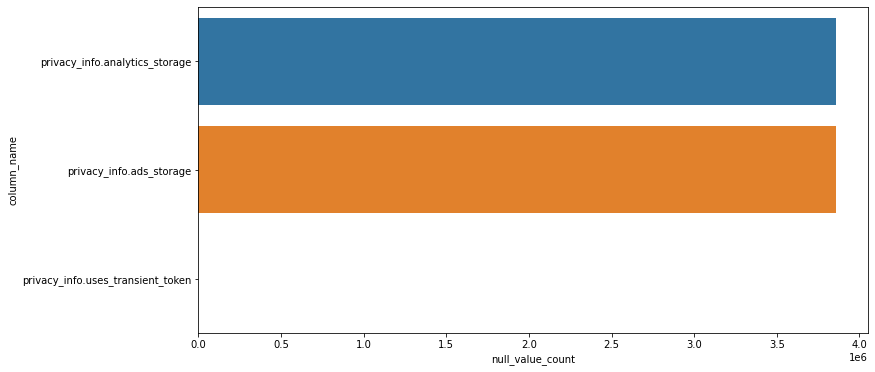

```python
null_count_plot(privacy_info_null_count,'null_value_count','column_name')
```

```python
privacy_info_null_count
```

|  | column_name | null_value_count |
| --- | --- | --- |
| 0 | privacy_info.analytics_storage | 3859763 |
| 1 | privacy_info.ads_storage | 3859763 |
| 2 | privacy_info.uses_transient_token | 0 |

#### The above information shows that the privacy_info.analytics_storage, privacy_info.ads_storage columns non null values is zero.

#### Let's see the device column and its field null value count.

```python
field_list=['device.category','device.mobile_brand_name','device.mobile_model_name',
            'device.mobile_marketing_name','device.mobile_os_hardware_model',
            'device.operating_system','device.operating_system_version',
            'device.vendor_id','device.advertising_id','device.language','device.is_limited_ad_tracking',
            'device.time_zone_offset_seconds','device.web_info.browser','device.web_info.browser_version']

device_null_count=query_to_df(field_list)
```

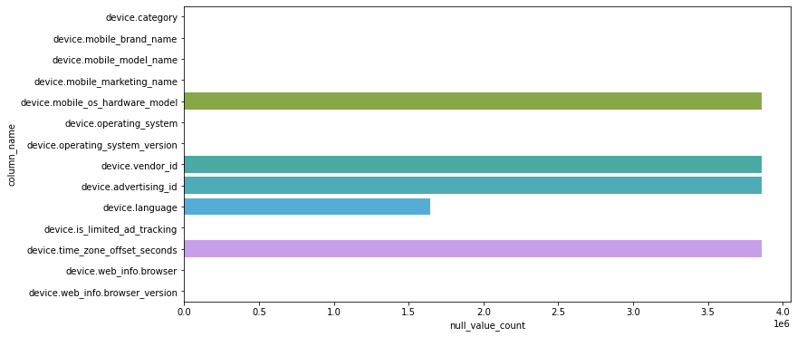

```python
null_count_plot(device_null_count,'null_value_count','column_name')
```

```python
device_null_count
```

|  | column_name | null_value_count |
| --- | --- | --- |
| 0 | device.category | 0 |
| 1 | device.mobile_brand_name | 0 |
| 2 | device.mobile_model_name | 0 |
| 3 | device.mobile_marketing_name | 0 |
| 4 | device.mobile_os_hardware_model | 3859763 |
| 5 | device.operating_system | 0 |
| 6 | device.operating_system_version | 0 |
| 7 | device.vendor_id | 3859763 |
| 8 | device.advertising_id | 3859763 |
| 9 | device.language | 1645027 |
| 10 | device.is_limited_ad_tracking | 0 |
| 11 | device.time_zone_offset_seconds | 3859763 |
| 12 | device.web_info.browser | 0 |
| 13 | device.web_info.browser_version | 0 |

#### The above information exlain that the device.mobile_os_hardware_model, device.vendor_id, device.advertising_id , device.time_zone_offset_seconds parameter's non null value is zero.

#### device. language parameter has 1645027 null values.

#### Let's see the geo column and its field null value count.

```python
field_list=['geo.continent','geo.sub_continent','geo.country','geo.region','geo.city','geo.metro']
geo_null_count=query_to_df(field_list)
```

```python
geo_null_count
```

|  | column_name | null_value_count |
| --- | --- | --- |
| 0 | geo.continent | 0 |
| 1 | geo.sub_continent | 0 |
| 2 | geo.country | 0 |
| 3 | geo.region | 0 |
| 4 | geo.city | 0 |
| 5 | geo.metro | 0 |

#### The above information explains that the geo fields don't have any null values.

#### Let's see the app_info column and its field null value count.

```python
field_list=['app_info.id','app_info.version','app_info.install_store','app_info.firebase_app_id','app_info.install_source']
app_info_null_count=query_to_df(field_list)
```

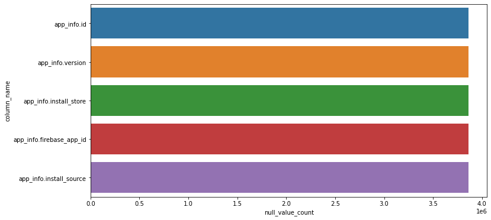

```python
null_count_plot(app_info_null_count,'null_value_count','column_name')
```

```python
app_info_null_count
```

|  | column_name | null_value_count |
| --- | --- | --- |
| 0 | app_info.id | 3859763 |
| 1 | app_info.version | 3859763 |
| 2 | app_info.install_store | 3859763 |
| 3 | app_info.firebase_app_id | 3859763 |
| 4 | app_info.install_source | 3859763 |

#### The above information explains that all the app_info fields don't have any values.

#### Let's see the traffic_source column and its field null value count.

```python
field_list=['traffic_source.medium','traffic_source.name','traffic_source.source']
traffic_source_null_count=query_to_df(field_list)
```

```python
traffic_source_null_count
```

|  | column_name | null_value_count |
| --- | --- | --- |
| 0 | traffic_source.medium | 0 |
| 1 | traffic_source.name | 0 |
| 2 | traffic_source.source | 0 |

#### The above information explains that traffic_source column fields don't have any null values.

#### Let's see event_diemesntions column null value count.

```python
query=f"""SELECT
  sum(CASE WHEN event_dimensions.hostname IS NULL THEN 1 ELSE 0 END) as event_dimensions_hostname
  FROM
    `{PROJECT_ID_DATA}.{DATASET_ID_DATA}.{TABLE_ID_TRAIN}`
  """
query_job = client.query(query)
query_job.to_dataframe()
```

|  | event_dimensions_hostname |
| --- | --- |
| 0 | 3859763 |

#### The above information exlains that the event_dimensions column has zero non null value.

#### Let's see the ecommerce column and its field null value count.

```python
field_list=['ecommerce.total_item_quantity','ecommerce.purchase_revenue_in_usd','ecommerce.purchase_revenue',
            'ecommerce.refund_value_in_usd','ecommerce.refund_value','ecommerce.shipping_value_in_usd',
            'ecommerce.shipping_value','ecommerce.tax_value_in_usd','ecommerce.tax_value',
            'ecommerce.unique_items','ecommerce.transaction_id']

ecommerce_null_count=query_to_df(field_list)
```

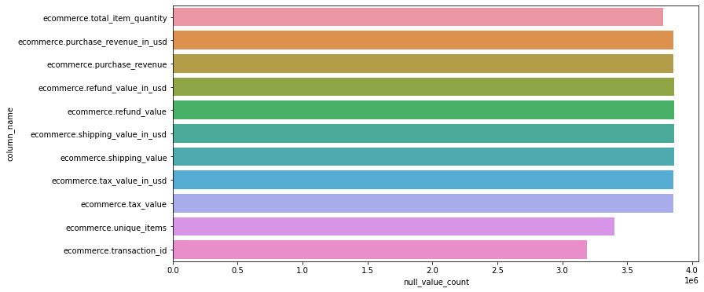

```python
null_count_plot(ecommerce_null_count,'null_value_count','column_name')
```

```python
ecommerce_null_count
```

|  | column_name | null_value_count |
| --- | --- | --- |
| 0 | ecommerce.total_item_quantity | 3775348 |
| 1 | ecommerce.purchase_revenue_in_usd | 3854613 |
| 2 | ecommerce.purchase_revenue | 3855007 |
| 3 | ecommerce.refund_value_in_usd | 3859763 |
| 4 | ecommerce.refund_value | 3859763 |
| 5 | ecommerce.shipping_value_in_usd | 3859763 |
| 6 | ecommerce.shipping_value | 3859763 |
| 7 | ecommerce.tax_value_in_usd | 3855007 |
| 8 | ecommerce.tax_value | 3855007 |
| 9 | ecommerce.unique_items | 3399893 |
| 10 | ecommerce.transaction_id | 3190157 |

```python
ecommerce_null_count.apply(lambda x:x['null_value_count']/3859763,axis=1)
```

```
0     0.978129
1     0.998666
2     0.998768
3     1.000000
4     1.000000
5     1.000000
6     1.000000
7     0.998768
8     0.998768
9     0.880855
10    0.826516
dtype: float64
```

#### The above information explains that all e-commerce fields have more than 80% null values.

#### Let's see the users's average long term value distribution

```python
query=f"""
  SELECT
  AVG(ltv) as Average_ltv
  FROM
  `{PROJECT_ID_DATA}.{DATASET_ID_DATA}.{TABLE_ID_TRAIN}` group by user_pseudo_id
  """
query_job = client.query(query)
avg_ltv = query_job.to_dataframe()
```

```
Large dataset detected, using 10000 random samples for the plots. Summary statistics are still based on the entire dataset.
```

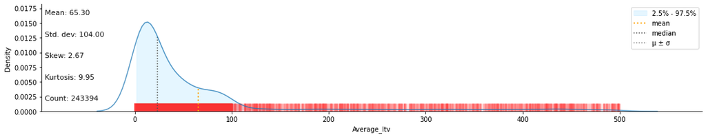

```python
klib.dist_plot(avg_ltv['Average_ltv'])
```

```python
avg_ltv['Average_ltv'].describe()
```

```
count    243394.000000
mean         65.296333
std         104.004247
min           0.000210
25%          10.328171
50%          23.225712
75%          67.625533
max        3360.000000
Name: Average_ltv, dtype: float64
```

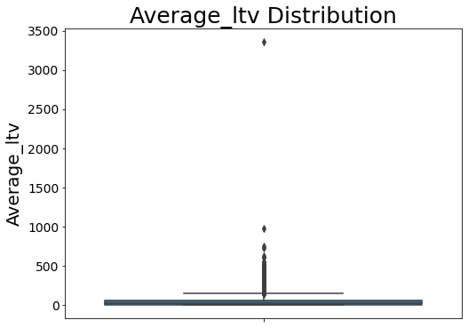

```python
box_plot(avg_ltv,'Average_ltv',rot=90)
```

#### The above histogram plot and summary explain that the average ltv is right-skewed (positively skewed).

#### The average ltv ranges from 0.000210 to 3360.

#### The average of average ltv is 65.296.

#### The boxplot explains that there are outliers above the third quartile.

#### Let's see the available event informations

```python
query=f"""
  SELECT event_name,
  count(distinct user_pseudo_id) as event_count
  FROM
  `{PROJECT_ID_DATA}.{DATASET_ID_DATA}.{TABLE_ID_TRAIN}` group by event_name
  """
query_job=client.query(query)
event_type=query_job.to_dataframe()
event_type=event_type.sort_values('event_count',ascending=False)
```

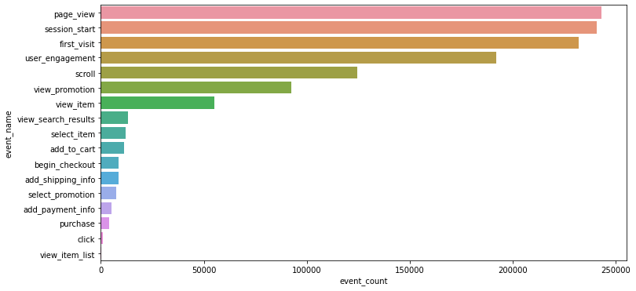

```python
_=plt.figure(figsize=(12,6))
_=sns.barplot(data=event_type  ,
              y='event_name',x='event_count');
```

```python
event_type
```

|  | event_name | event_count |
| --- | --- | --- |
| 3 | page_view | 243068 |
| 1 | session_start | 240668 |
| 4 | first_visit | 231830 |
| 0 | user_engagement | 191970 |
| 2 | scroll | 124415 |
| 6 | view_promotion | 92300 |
| 5 | view_item | 55207 |
| 7 | view_search_results | 12970 |
| 13 | select_item | 11872 |
| 15 | add_to_cart | 11281 |
| 11 | begin_checkout | 8739 |
| 9 | add_shipping_info | 8738 |
| 12 | select_promotion | 7371 |
| 8 | add_payment_info | 5193 |
| 14 | purchase | 3998 |
| 10 | click | 919 |
| 16 | view_item_list | 37 |

#### Let's see the user's average ltv distribution by different events.

```python
query=f"""
  select user_pseudo_id, event_name , avg(ltv) as event_wise_avrage_ltv
  FROM
  `{PROJECT_ID_DATA}.{DATASET_ID_DATA}.{TABLE_ID_TRAIN}` group by user_pseudo_id, event_name
  """
query_job=client.query(query)
event_avg_ltv=query_job.to_dataframe()
```

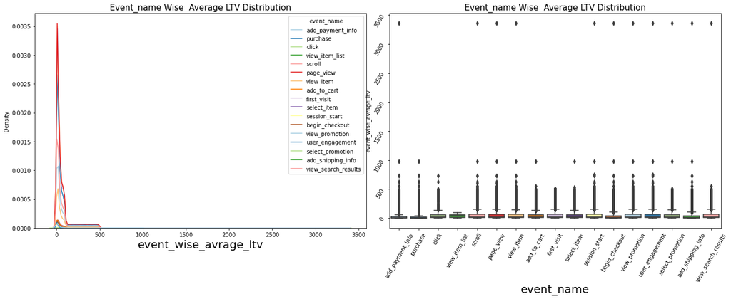

```python
side_by_side_plot(event_avg_ltv,'event_name','event_wise_avrage_ltv',rot=60,title=' Average LTV')
```

```python
event_avg_ltv.groupby('event_name')['event_wise_avrage_ltv'].describe()
```

| event_name | count | mean | std | min | 25% | 50% | 75% | max |
| --- | --- | --- | --- | --- | --- | --- | --- | --- |
| add_payment_info | 5193.0 | 30.038233 | 80.112460 | 0.012971 | 1.811321 | 7.151163 | 26.089959 | 3360.000000 |
| add_shipping_info | 8738.0 | 44.592329 | 92.675723 | 0.001387 | 3.408611 | 13.512791 | 43.409149 | 3360.000000 |
| add_to_cart | 11281.0 | 54.350028 | 94.562943 | 0.012971 | 6.297957 | 17.930704 | 55.912941 | 981.194690 |
| begin_checkout | 8739.0 | 44.587928 | 92.671333 | 0.001387 | 3.408771 | 13.511789 | 43.406214 | 3360.000000 |
| click | 919.0 | 61.380490 | 101.475386 | 0.112037 | 10.399877 | 24.651282 | 62.004593 | 731.909091 |
| first_visit | 231830.0 | 65.289657 | 103.802204 | 0.000210 | 10.339539 | 23.185543 | 67.625292 | 499.993208 |
| page_view | 243068.0 | 65.280284 | 103.981843 | 0.000210 | 10.326923 | 23.217286 | 67.616204 | 3360.000000 |
| purchase | 3998.0 | 20.686482 | 51.057887 | 0.032252 | 1.398058 | 4.323493 | 16.757347 | 981.194690 |
| scroll | 124415.0 | 64.288642 | 103.406325 | 0.000210 | 10.078233 | 22.514066 | 66.607495 | 3360.000000 |
| select_item | 11872.0 | 58.297828 | 97.932479 | 0.007471 | 7.878200 | 19.344283 | 59.888329 | 981.194690 |
| select_promotion | 7371.0 | 62.587792 | 109.511335 | 0.014876 | 9.369737 | 20.393112 | 62.886939 | 3360.000000 |
| session_start | 240668.0 | 65.277614 | 103.986637 | 0.000210 | 10.326043 | 23.213717 | 67.622594 | 3360.000000 |
| user_engagement | 191970.0 | 65.096580 | 103.977261 | 0.000210 | 10.240451 | 23.032826 | 67.395950 | 3360.000000 |
| view_item | 55207.0 | 62.444117 | 102.463257 | 0.000275 | 9.383827 | 21.017276 | 64.806028 | 3360.000000 |
| view_item_list | 37.0 | 39.139336 | 28.784023 | 0.799886 | 15.031859 | 36.622741 | 58.367239 | 97.423547 |
| view_promotion | 92300.0 | 64.350569 | 103.637263 | 0.000210 | 9.879568 | 22.428427 | 66.784070 | 3360.000000 |
| view_search_results | 12970.0 | 63.149595 | 105.672073 | 0.001387 | 9.562740 | 21.768476 | 66.407390 | 3360.000000 |

#### The above plot and summary explain that there is a mean difference between the different events.

#### Let's the ltv distrubtion by the date

```python
query=f"""
  SELECT event_date,
  min(ltv) as Date_wise_min_ltv,
  avg(ltv) as Date_wise_avrage_ltv,
  max(ltv) as Date_wise_max_ltv
  FROM
  `{PROJECT_ID_DATA}.{DATASET_ID_DATA}.{TABLE_ID_TRAIN}` group by event_date
  """
query_job=client.query(query)
event_date_ltv=query_job.to_dataframe()
```

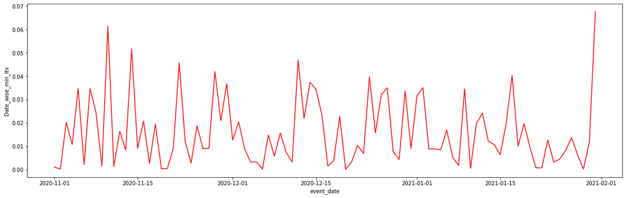

```python
_=plt.figure(figsize=(20,6))
sns.lineplot(x=pd.to_datetime(event_date_ltv['event_date']),y=event_date_ltv['Date_wise_min_ltv'],color='red');
```

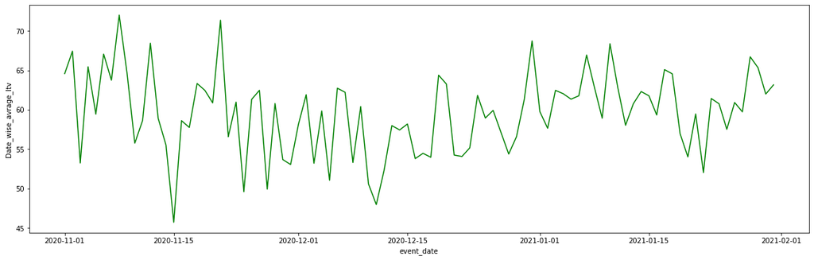

```python
_=plt.figure(figsize=(20,6));
sns.lineplot(x=pd.to_datetime(event_date_ltv['event_date']),y=event_date_ltv['Date_wise_avrage_ltv'],color='green');
```

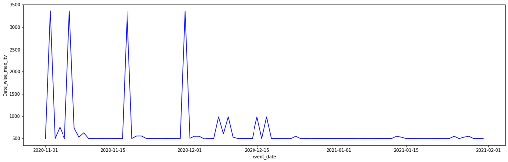

```python
_=plt.figure(figsize=(20,6));
sns.lineplot(x=pd.to_datetime(event_date_ltv['event_date']),y=event_date_ltv['Date_wise_max_ltv'],color='blue');
```

#### The above plots explains the minimum, average, and maximum ltv of users over the 3 months.

#### Let's see the number of unique users over the 3 months.

```python
query=f"""
  SELECT event_date,
  count(distinct user_pseudo_id) unique_user_count
  FROM
  `{PROJECT_ID_DATA}.{DATASET_ID_DATA}.{TABLE_ID_TRAIN}` group by event_date
  """
query_job=client.query(query)
event_date_unique_user=query_job.to_dataframe()
```

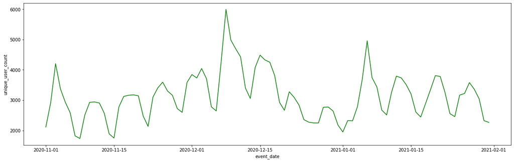

```python
_=plt.figure(figsize=(20,6));
sns.lineplot(x=pd.to_datetime(event_date_unique_user['event_date']),y=event_date_unique_user['unique_user_count'],color='green');
```

#### The above plot explains that more user activity was recorded in the month of December '2020 and January '2021.

#### Let's see the unique users count over the weeks of 3 months.

```python
query=f"""
  select EXTRACT(WEEK FROM TIMESTAMP_MICROS(event_timestamp)) as week,
  EXTRACT(YEAR FROM PARSE_DATE("%Y%m%d",event_date)) as Year,
  count(distinct user_pseudo_id) unique_user_count_week
  FROM
  `{PROJECT_ID_DATA}.{DATASET_ID_DATA}.{TABLE_ID_TRAIN}` group by 1,2
  """
query_job=client.query(query)
event_date_week_unique_user=query_job.to_dataframe()
event_date_week_unique_user=event_date_week_unique_user.sort_values('Year',ascending=True)
```

[figure not shown]

```python
fig=plt.subplots(figsize=(20, 8))
custom_palette = sns.color_palette("dark", 2)
colors=[col for col in custom_palette.as_hex()]
for i,(col,clr) in enumerate(zip(event_date_week_unique_user['Year'].unique(),colors)):
    _=plt.subplot(2,1,i+1)
    data=event_date_week_unique_user[event_date_week_unique_user['Year']==col]
    _=sns.lineplot(x=data['week'],y=data['unique_user_count_week'],color=clr)
    _=plt.title(str(col)+": LTV Over the Weeks",fontsize=15)
    _=plt.xlabel("")
    _=plt.ylabel("")
    _#=plt.xticks(fontsize=15)
    _=plt.tight_layout()
plt.show()
```

#### The above plot explains that in the year 2020, more activity was in weeks 49 and 50 of the year.

#### In the year 2021, more activity was in the weeks from 1 to 4 of the year.

#### Let's see the users average ltv over the 3 months by different events.

```python
query=f"""
  SELECT event_date,event_name,
  avg(ltv) as Event_type_date_wise_average_ltv,
  FROM
  `{PROJECT_ID_DATA}.{DATASET_ID_DATA}.{TABLE_ID_TRAIN}` group by event_date,event_name
  """
query_job=client.query(query)
event_type_date_ltv=query_job.to_dataframe()
```

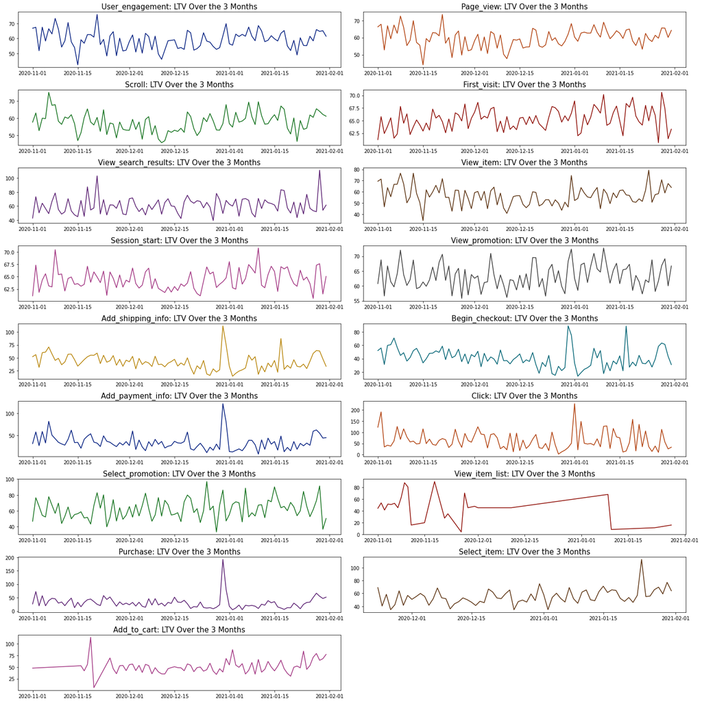

```python
fig=plt.subplots(figsize=(20, 20))
custom_palette = sns.color_palette("dark", 17)
colors=[col for col in custom_palette.as_hex()]
for i,(col,clr) in enumerate(zip(event_type_date_ltv['event_name'].unique(),colors)):
    _=plt.subplot(9,2,i+1)
    data=event_type_date_ltv[event_type_date_ltv['event_name']==col]
    _=sns.lineplot(x=pd.to_datetime(data['event_date']),y=data['Event_type_date_wise_average_ltv'],color=clr)
    _=plt.title(col.capitalize()+": LTV Over the 3 Months",fontsize=15)
    _=plt.xlabel("")
    _=plt.ylabel("")
    _#=plt.xticks(fontsize=15)
    _=plt.tight_layout()
plt.show()
```

#### Let's see the user's average ltv over the hours of the day.

```python
query=f"""
  select EXTRACT(HOUR FROM TIMESTAMP_MICROS(event_timestamp)) as Hour, avg(ltv) as Hour_wise_average_ltv,
  FROM
  `{PROJECT_ID_DATA}.{DATASET_ID_DATA}.{TABLE_ID_TRAIN}` group by 1
  """
query_job=client.query(query)
hour_ltv=query_job.to_dataframe()
hour_ltv=hour_ltv.sort_values('Hour',ascending=True)
hour_ltv=hour_ltv.replace({'Hour':{0:24}})
```

#### Let's create a function to convert the hour to part of the day.

```python
def hours2timing(x):
    if x in range(20,23):
        timing = 'Night'
    elif x in range(5,12):
        timing = 'Morning'
    elif x in range(12, 16):
        timing = 'Afternoon'
    elif x in range(16, 20):
        timing = 'Evening'
    elif x in [23,24,1,2,3,4]:
        timing = 'Midnight'
    else:
        timing = 'X'
    return timing
```

```python
hour_ltv['timings']=hour_ltv['Hour'].apply(hours2timing)
```

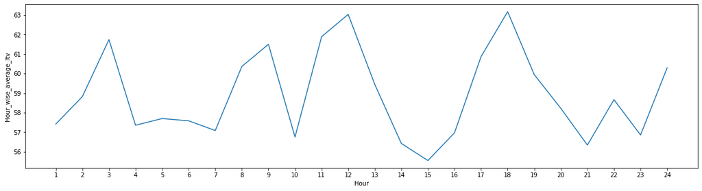

```python
_=plt.figure(figsize=(20,5))
sns.lineplot(x=hour_ltv['Hour'],y=hour_ltv['Hour_wise_average_ltv']);
_=plt.xticks([hour for hour in range(1,25)])
```

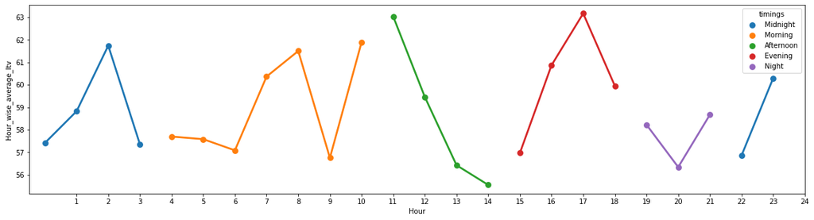

```python
_=plt.figure(figsize=(20,5))
sns.pointplot(data=hour_ltv,x='Hour',y='Hour_wise_average_ltv',hue='timings');
_=plt.xticks([hour for hour in range(1,25)])
```

#### Let's see the users average ltv over the weeks of 3 months.

```python
query=f"""
  select EXTRACT(WEEK FROM PARSE_DATE("%Y%m%d",event_date)) as Week,
  EXTRACT(YEAR FROM PARSE_DATE("%Y%m%d",event_date)) as Year,
  avg(ltv) as Week_wise_average_ltv,
  FROM
  `{PROJECT_ID_DATA}.{DATASET_ID_DATA}.{TABLE_ID_TRAIN}` group by 1,2
  """
query_job=client.query(query)
week_ltv=query_job.to_dataframe()
```

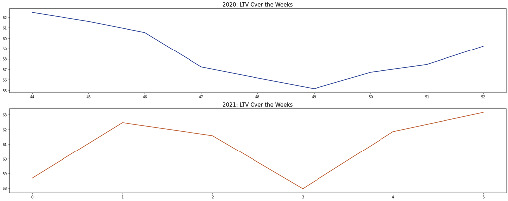

```python
fig=plt.subplots(figsize=(20, 8))
custom_palette = sns.color_palette("dark", 2)
colors=[col for col in custom_palette.as_hex()]
for i,(col,clr) in enumerate(zip(week_ltv['Year'].unique(),colors)):
    _=plt.subplot(2,1,i+1)
    data=week_ltv[week_ltv['Year']==col]
    _=sns.lineplot(x=data['Week'],y=data['Week_wise_average_ltv'],color=clr)
    _=plt.title(str(col)+": LTV Over the Weeks",fontsize=15)
    _=plt.xlabel("")
    _=plt.ylabel("")
    _#=plt.xticks(fontsize=15)
    _=plt.tight_layout()
plt.show()
```

#### Let's see users average ltv over the day of the 3 months week.

```python
query=f"""
  select EXTRACT(WEEK FROM PARSE_DATE("%Y%m%d",event_date)) as Week,
  EXTRACT(DAYOFWEEK FROM PARSE_DATE("%Y%m%d",event_date)) as day_of_week,
  EXTRACT(YEAR FROM PARSE_DATE("%Y%m%d",event_date)) as year,
  avg(ltv) as day_week_wise_average_ltv,
  FROM
  `{PROJECT_ID_DATA}.{DATASET_ID_DATA}.{TABLE_ID_TRAIN}` group by 1,2,3 order by year asc,Week asc
  """
query_job=client.query(query)
day_week_ltv=query_job.to_dataframe()
```

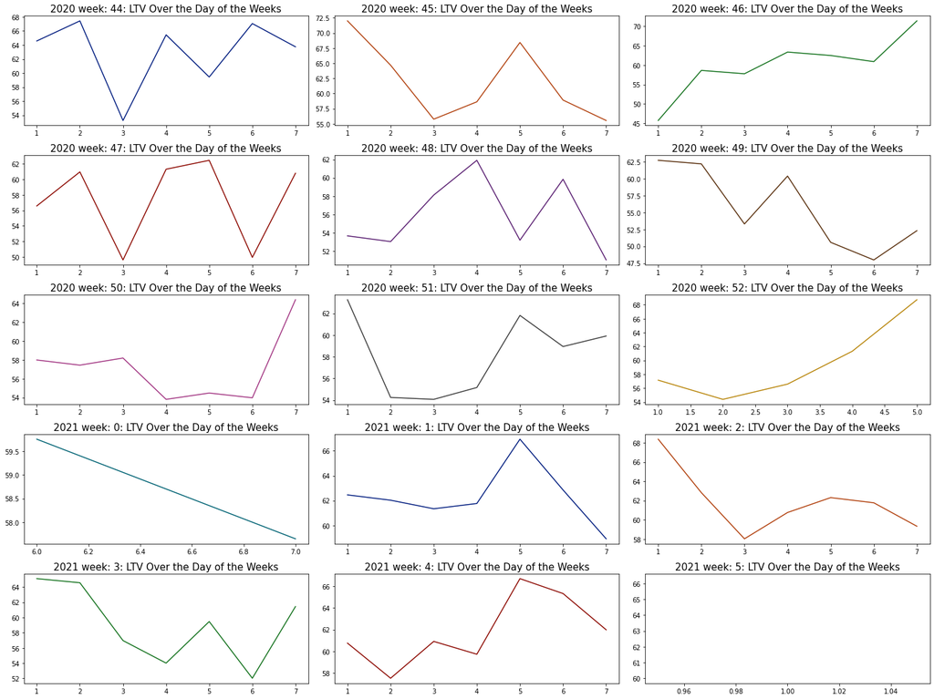

```python
fig=plt.subplots(figsize=(20, 15))
custom_palette = sns.color_palette("dark", 15)
colors=[col for col in custom_palette.as_hex()]
for i,(col,clr) in enumerate(zip(day_week_ltv['Week'].unique(),colors)):
    _=plt.subplot(5,3,i+1)
    data=day_week_ltv[day_week_ltv['Week']==col]
    _=sns.lineplot(x=data['day_of_week'],y=data['day_week_wise_average_ltv'],color=clr)
    _=plt.title(str(data['year'].unique()[0])+' week: '+str(col)+": LTV Over the Day of the Weeks",fontsize=15)
    _=plt.xlabel("")
    _=plt.ylabel("")
    _#=plt.xticks(fontsize=15)
    _=plt.tight_layout()
plt.show()
```

#### The above plot shows that in each week of 3 months, the average ltv of users shows a different pattern.

#### Let's explore the device column and its field.

```python
query=f"""
  select avg(event_value_in_usd) as avg_event_value ,avg(ltv) as average_ltv
  FROM
  `{PROJECT_ID_DATA}.{DATASET_ID_DATA}.{TABLE_ID_TRAIN}` where event_value_in_usd is not null group by user_pseudo_id
  """
query_job=client.query(query)
val_ltv=query_job.to_dataframe()
```

```python
device_field_list=['device.category','device.mobile_brand_name','device.mobile_model_name',
                   'device.web_info.browser']
```

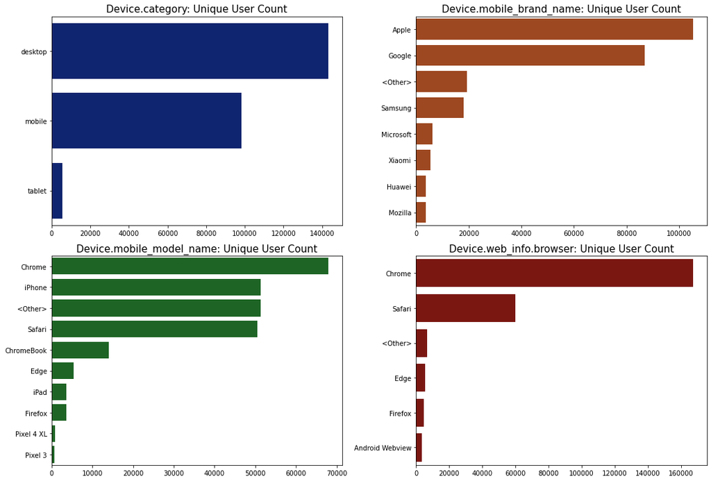

```python
fig=plt.subplots(figsize=(15, 20))
custom_palette = sns.color_palette("dark", 4)
colors=[col for col in custom_palette.as_hex()]
for i,(col,clr) in enumerate(zip(device_field_list,colors)):
    query=f"""
    select {col} ,count(distinct user_pseudo_id) as user_count
    FROM
    `{PROJECT_ID_DATA}.{DATASET_ID_DATA}.{TABLE_ID_TRAIN}`  group by {col} order by user_count desc
    """
    query_job=client.query(query)
    df=query_job.to_dataframe()
    _=plt.subplot(4,2,i+1)
    _=sns.barplot(x=df['user_count'],y=df.iloc[:,0],color=clr)
    _=plt.title(col.capitalize()+": Unique User Count",fontsize=15)
    _=plt.xlabel("")
    _=plt.ylabel("")
    _#=plt.xticks(fontsize=15)
    _=plt.tight_layout()
plt.show()
```

#### The above plot explains that the more users using the,

- desktop device
- apple, google brand mobile is most common among the users
- Chrome and iPhone are the most common mobile model name
- Chrome browser is the most common web browser among all devices.

#### Let's explore geo fields column and unique user by categories.

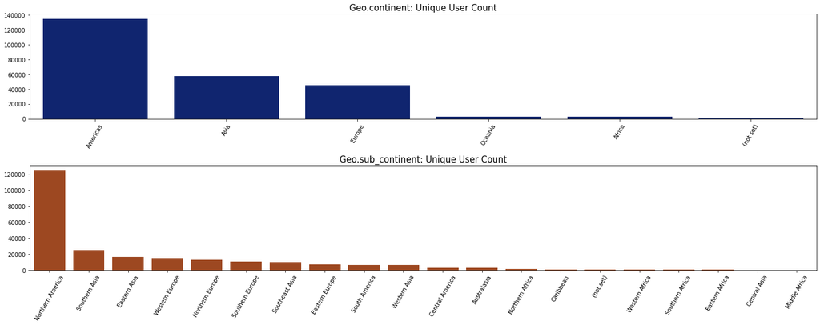

```python
geo_field_list=['geo.continent','geo.sub_continent']
fig=plt.subplots(figsize=(20, 8))
custom_palette = sns.color_palette("dark", 2)
colors=[col for col in custom_palette.as_hex()]
for i,(col,clr) in enumerate(zip(geo_field_list,colors)):
    query=f"""
    select {col} ,count(distinct user_pseudo_id) as user_count
    FROM
    `{PROJECT_ID_DATA}.{DATASET_ID_DATA}.{TABLE_ID_TRAIN}`  group by {col} order by user_count desc
    """
    query_job=client.query(query)
    df=query_job.to_dataframe()
    _=plt.subplot(2,1,i+1)
    _=sns.barplot(x=df.iloc[:,0],y=df['user_count'],color=clr)
    _=plt.title(col.capitalize()+": Unique User Count",fontsize=15)
    _=plt.xlabel("")
    _=plt.ylabel("")
    _=plt.xticks(rotation=60)
    _=plt.tight_layout()
plt.show()
```

#### The above plot explains that most of the users are from north America.

#### Let's explore traffic_source fields column and unique user by categories.

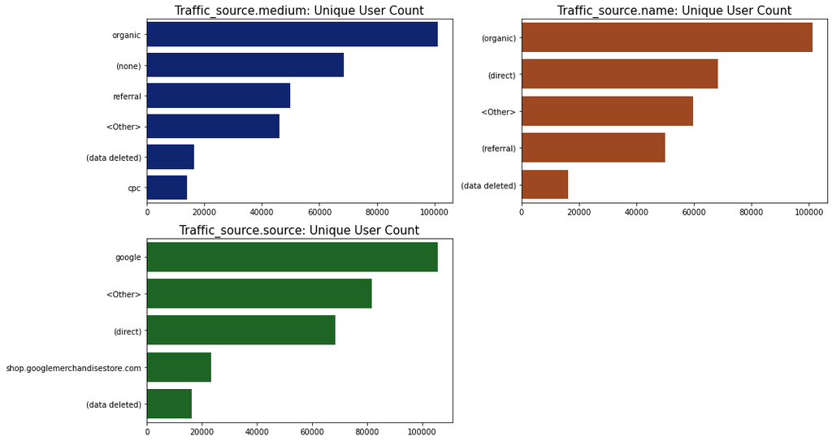

```python
traffic_source_field_list=['traffic_source.medium','traffic_source.name','traffic_source.source']
fig=plt.subplots(figsize=(15, 8))
custom_palette = sns.color_palette("dark", 3)
colors=[col for col in custom_palette.as_hex()]
for i,(col,clr) in enumerate(zip(traffic_source_field_list,colors)):
    query=f"""
    select {col} ,count(distinct user_pseudo_id) as user_count
    FROM
    `{PROJECT_ID_DATA}.{DATASET_ID_DATA}.{TABLE_ID_TRAIN}`  group by {col} order by user_count desc
    """
    query_job=client.query(query)
    df=query_job.to_dataframe()
    _=plt.subplot(2,2,i+1)
    _=sns.barplot(x=df['user_count'],y=df.iloc[:,0],color=clr)
    _=plt.title(col.capitalize()+": Unique User Count",fontsize=15)
    _=plt.xlabel("")
    _=plt.ylabel("")
    _#=plt.xticks(fontsize=15)
    _=plt.tight_layout()
plt.show()
```

#### Let's see event_params nested field's page_title column and see how many unique user by page_title category.

```python
query=f"""
  select ep.value.string_value, count(distinct user_pseudo_id) as unique_user_count
  FROM
  `{PROJECT_ID_DATA}.{DATASET_ID_DATA}.{TABLE_ID_TRAIN}`,unnest(event_params) as ep
   where ep.key='page_title' group by 1 order by unique_user_count desc
  """
query_job=client.query(query)
event_page_unique_user=query_job.to_dataframe()
```

```python
event_page_unique_user.head()
```

|  | string_value | unique_user_count |
| --- | --- | --- |
| 0 | Home | 101108 |
| 1 | Google Online Store | 52243 |
| 2 | Apparel \| Google Merchandise Store | 45237 |
| 3 | YouTube \| Shop by Brand \| Google Merchandise S... | 24049 |
| 4 | Shopping Cart | 20462 |

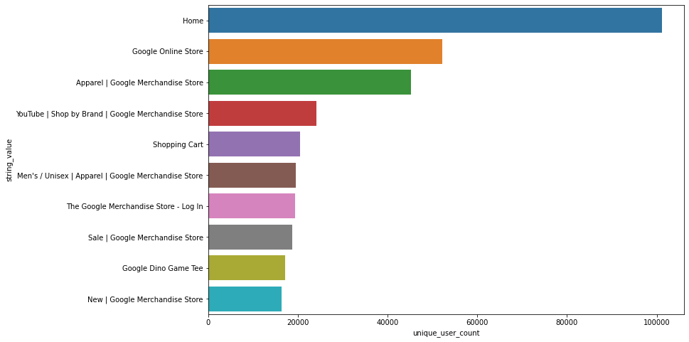

```python
_=plt.figure(figsize=(12,8))
_=sns.barplot(data=event_page_unique_user.nlargest(10,'unique_user_count') ,
              x='unique_user_count',y='string_value');
```

#### The above plot explains that the most of user activity was recorded from google home and google store.

#### Let's see the user's average engagement time distribution.

```python
query=f"""
  select user_pseudo_id as user_id, avg(ep.value.int_value) average_engagement_time_msec
  FROM
  `{PROJECT_ID_DATA}.{DATASET_ID_DATA}.{TABLE_ID_TRAIN}`,unnest(event_params) as ep
  where ep.key='engagement_time_msec' group by 1
  """
query_job=client.query(query)
user_avg_eng_time=query_job.to_dataframe()
```

```
Large dataset detected, using 10000 random samples for the plots. Summary statistics are still based on the entire dataset.
```

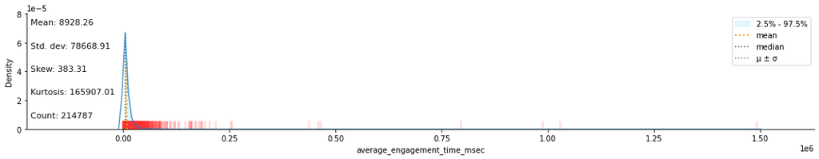

```python
klib.dist_plot(user_avg_eng_time['average_engagement_time_msec'])
```

```python
user_avg_eng_time['average_engagement_time_msec'].describe()
```

```
count    2.147870e+05
mean     8.928263e+03
std      7.866891e+04
min      1.000000e+00
25%      2.361833e+03
50%      4.970333e+03
75%      9.934946e+03
max      3.418754e+07
Name: average_engagement_time_msec, dtype: float64
```

#### The above histogram plot and summary explain that the average engagement time is right-skewed (positively skewed).